# Trajectory analysis with monocle

```r
package.version("monocle")
```

```
[1] "2.22.0"
```

**Goal of this workshop:** Learn to analyze cell trajectories with monocle

**What’s covered in this workshop:**

- Merge Seurat objects
- Create a Monocle object
- Run trajectory analysis
- Test for DE over pseudotime

**Data source:** Christian et al. 2021 Cell Reports (https://doi.org/10.1016/j.celrep.2021.109118)

**METHOD DETAILS, Single-cell RNA-seq analysis, page e4** - Analysis: “To infer the lineage development of TEFF / EM to TCM, we used Monocle package v2.5.4 (Qiu et al., 2017). The top 2000 significant DEGs were chosen to order genes for trajectory reconstruction using the DDRTree method followed by dimension reduction, cell trajectory inference and pseudo-time measurements, which were computed via reversed graph embedding.”

## Load data

Load Seurat objects into R

```r
seulist <- readRDS(file.path(intermeddir, "seulist_drc.rds"))

trm <- seulist[["Trm"]]
disttrm <- seulist[["disTrm"]]
tem <- seulist[["Tem"]]
```

## 1. Merge Seurat objects

Merge the seurat objects together so that there is 1 object that includes all samples.

Since we will be merging the cells, it is useful to add a prefix to the cell names that identify which sample the cell came from. This information can also be stored in the metadata.

```r
Cells(trm)[1:10]
```

```
 [1] "AAACCTGGTCTTGCGG" "AAACGGGAGGCTCAGA" "AAACGGGGTCAACATC" "AAACGGGTCTTGAGAC" "AAAGATGGTAGGGTAC" "AAAGATGTCCTACAGA"
 [7] "AAAGCAACACACCGAC" "AAATGCCAGCTAGTTC" "AACCATGCACGGCCAT" "AACCATGCAGTTAACC"
```

```r
trm.rn <- RenameCells(trm, add.cell.id = 'Trm')
Cells(trm.rn)[1:10]
```

```
 [1] "Trm_AAACCTGGTCTTGCGG" "Trm_AAACGGGAGGCTCAGA" "Trm_AAACGGGGTCAACATC" "Trm_AAACGGGTCTTGAGAC" "Trm_AAAGATGGTAGGGTAC"
 [6] "Trm_AAAGATGTCCTACAGA" "Trm_AAAGCAACACACCGAC" "Trm_AAATGCCAGCTAGTTC" "Trm_AACCATGCACGGCCAT" "Trm_AACCATGCAGTTAACC"
```

```r
# do this for the remaining samples that will be merged
tem.rn <- RenameCells(tem, add.cell.id='Tem')
disttrm.rn <- RenameCells(disttrm, add.cell.id='MucosalTrm')
```

Merge Trm and MucosalTrm cells

```r
comb <- merge(trm.rn, disttrm.rn)

comb@meta.data %>%
  group_by(orig.ident) %>%
  summarize(ncells = length(orig.ident))
```

| orig.ident | ncells |
| --- | --- |
| disTrm | 863 |
| Trm | 459 |

Add the Tem cells

```r
comb <- merge(comb, tem.rn)

comb@meta.data %>%
  group_by(orig.ident) %>%
  summarize(ncells = length(orig.ident))
```

| orig.ident | ncells |
| --- | --- |
| disTrm | 863 |
| Tem | 1457 |
| Trm | 459 |

Check the cell names

```r
dim(comb@meta.data) #2779 cells in total
```

```
[1] 2779    6
```

```r
Cells(comb) %>%
  str_split("_") %>%
  map_dfr(~data.frame(prefix = .x[1], orig.cellname = .x[2])) %>%
  mutate(new.cellname = Cells(comb)) -> cellname.df

cellname.df %>%
  group_by(prefix) %>%
  summarize(ncells = length(orig.cellname))
```

| prefix | ncells |
| --- | --- |
| MucosalTrm | 863 |
| Tem | 1457 |
| Trm | 459 |

## 2. Create a Monocle object

Monocle uses a different type of object, a “CellDataSet” object, to store single-cell data. There are three data elements to a CellDataSet object:

- **cellData**: expression matrix with rows as genes and columns as cells
- **phenoData**: data frame containing attributes of individual cells
- **featureData**: data frame containing attributes of gene features

Extract the count matrix with rows as genes and columns as cells.

```r
cd <- comb@assays$RNA@counts
dim(cd)
```

```
[1] 13009  2779
```

```r
rownames(cd)[1:5]
```

```
[1] "Mrpl15"  "Lypla1"  "Tcea1"   "Atp6v1h" "Rb1cc1"
```

```r
colnames(cd)[1:5]
```

```
[1] "Trm_AAACCTGGTCTTGCGG" "Trm_AAACGGGAGGCTCAGA" "Trm_AAACGGGGTCAACATC" "Trm_AAACGGGTCTTGAGAC" "Trm_AAAGATGGTAGGGTAC"
```

Extract the cell-level data.

```r
pd <- comb@meta.data
dim(pd)
```

```
[1] 2779    6
```

```r
rownames(pd)[1:5]
```

```
[1] "Trm_AAACCTGGTCTTGCGG" "Trm_AAACGGGAGGCTCAGA" "Trm_AAACGGGGTCAACATC" "Trm_AAACGGGTCTTGAGAC" "Trm_AAAGATGGTAGGGTAC"
```

Extract the gene-level metadata.

```r
rownames(comb)[1:5]
```

```
[1] "Mrpl15"  "Lypla1"  "Tcea1"   "Atp6v1h" "Rb1cc1"
```

```r
fd <- data.frame(gene_short_name = rownames(comb),
                 row.names = rownames(comb))
dim(fd)
```

```
[1] 13009     1
```

```r
row.names(fd)[1:5]
```

```
[1] "Mrpl15"  "Lypla1"  "Tcea1"   "Atp6v1h" "Rb1cc1"
```

Create the CellDataSet object.

```r
pd.adf <- new("AnnotatedDataFrame", data = pd)
fd.adf <- new("AnnotatedDataFrame", data = fd)

cds <- newCellDataSet(cellData = cd,
                      phenoData = pd.adf,
                      featureData = fd.adf)
```

## 3. Run tranjectory analysis

Before running the trajectory analysis, the counts need to be preprocessed in the following ways.

```r
cds.es <- estimateSizeFactors(cds)
head(pData(cds))
```

|  | orig.ident | nCount_RNA | nFeature_RNA | percent.mt | RNA_snn_res.0.6 | seurat_clusters | Size_Factor |
| --- | --- | --- | --- | --- | --- | --- | --- |
| Trm_AAACCTGGTCTTGCGG | Trm | 4480 | 1544 | 2.343750 | 1 | 1 | NA |
| Trm_AAACGGGAGGCTCAGA | Trm | 7628 | 1696 | 3.224961 | 0 | 0 | NA |
| Trm_AAACGGGGTCAACATC | Trm | 4830 | 1572 | 2.939959 | 0 | 0 | NA |
| Trm_AAACGGGTCTTGAGAC | Trm | 8058 | 2239 | 2.593696 | 1 | 1 | NA |
| Trm_AAAGATGGTAGGGTAC | Trm | 2378 | 1003 | 3.195963 | 0 | 0 | NA |
| Trm_AAAGATGTCCTACAGA | Trm | 2934 | 1027 | 2.453988 | 3 | 3 | NA |

```r
head(pData(cds.es))
```

|  | orig.ident | nCount_RNA | nFeature_RNA | percent.mt | RNA_snn_res.0.6 | seurat_clusters | Size_Factor |
| --- | --- | --- | --- | --- | --- | --- | --- |
| Trm_AAACCTGGTCTTGCGG | Trm | 4480 | 1544 | 2.343750 | 1 | 1 | 1.2502888 |
| Trm_AAACGGGAGGCTCAGA | Trm | 7628 | 1696 | 3.224961 | 0 | 0 | 2.1288399 |
| Trm_AAACGGGGTCAACATC | Trm | 4830 | 1572 | 2.939959 | 0 | 0 | 1.3479676 |
| Trm_AAACGGGTCTTGAGAC | Trm | 8058 | 2239 | 2.593696 | 1 | 1 | 2.2488453 |
| Trm_AAAGATGGTAGGGTAC | Trm | 2378 | 1003 | 3.195963 | 0 | 0 | 0.6636577 |
| Trm_AAAGATGTCCTACAGA | Trm | 2934 | 1027 | 2.453988 | 3 | 3 | 0.8188275 |

```r
cds.ds <- estimateDispersions(cds.es)
```

```
Removing 26 outliers
```

```r
#head(dispersionTable(cds.es)) # if you haven't already estimated the dispersion, this will throw an error
head(dispersionTable(cds.ds))
```

|  | gene_id | mean_expression | dispersion_fit | dispersion_empirical |
| --- | --- | --- | --- | --- |
| 1 | Mrpl15 | 0.22310305 | 1.0958020 | 0.0000000 |
| 2 | Lypla1 | 0.14178132 | 1.5509077 | 0.0000000 |
| 3 | Tcea1 | 0.31170279 | 0.8702657 | 0.2548530 |
| 4 | Atp6v1h | 0.13508195 | 1.6128301 | 0.1505939 |
| 5 | Rb1cc1 | 0.14033596 | 1.5637671 | 0.3681927 |
| 6 | 4732440D04Rik | 0.03058207 | 6.0908067 | 1.4588278 |

Filter out genes with low expression.

Notice that the detectGenes() function sets the expression detection threshold, calculates the number of cells that express each gene above that threshold, and adds that value to the feature dataframe.

```r
head(fData(cds.ds))
```

|  | gene_short_name |
| --- | --- |
| Mrpl15 | Mrpl15 |
| Lypla1 | Lypla1 |
| Tcea1 | Tcea1 |
| Atp6v1h | Atp6v1h |
| Rb1cc1 | Rb1cc1 |
| 4732440D04Rik | 4732440D04Rik |

```r
cds.filt <- detectGenes(cds.ds, min_expr = 0.1) # set the detection threshold to 0.1
head(fData(cds.filt))
```

|  | gene_short_name | num_cells_expressed |
| --- | --- | --- |
| Mrpl15 | Mrpl15 | 609 |
| Lypla1 | Lypla1 | 410 |
| Tcea1 | Tcea1 | 758 |
| Atp6v1h | Atp6v1h | 372 |
| Rb1cc1 | Rb1cc1 | 373 |
| 4732440D04Rik | 4732440D04Rik | 87 |

Identify genes that are expressed in at least 100 cells. These genes will be retained.

```r
dim(fData(cds.filt))[1] # 13009 features in total
```

```
[1] 13009
```

```r
fData(cds.filt) %>%
  filter(num_cells_expressed >= 100) %>%
  row.names() -> expressed_genes
expressed_genes[1:5]
```

```
[1] "Mrpl15"  "Lypla1"  "Tcea1"   "Atp6v1h" "Rb1cc1"
```

```r
length(expressed_genes) # 6543 features that are expressed in at least 100 cells
```

```
[1] 6543
```

Select genes

```r
cds.filt # assayData: 13009 features, 2779 samples
```

```
CellDataSet (storageMode: environment)
assayData: 13009 features, 2779 samples
  element names: exprs
protocolData: none
phenoData
  sampleNames: Trm_AAACCTGGTCTTGCGG Trm_AAACGGGAGGCTCAGA ... Tem_TTTGTCACATCTCCCA (2779 total)
  varLabels: orig.ident nCount_RNA ... num_genes_expressed (8 total)
  varMetadata: labelDescription
featureData
  featureNames: Mrpl15 Lypla1 ... Adrb1 (13009 total)
  fvarLabels: gene_short_name num_cells_expressed
  fvarMetadata: labelDescription
experimentData: use 'experimentData(object)'
Annotation:
```

```r
cds.exprs <- cds.filt[expressed_genes,]
cds.exprs # assayData: 6543 features, 2779 samples
```

```
CellDataSet (storageMode: environment)
assayData: 6543 features, 2779 samples
  element names: exprs
protocolData: none
phenoData
  sampleNames: Trm_AAACCTGGTCTTGCGG Trm_AAACGGGAGGCTCAGA ... Tem_TTTGTCACATCTCCCA (2779 total)
  varLabels: orig.ident nCount_RNA ... num_genes_expressed (8 total)
  varMetadata: labelDescription
featureData
  featureNames: Mrpl15 Lypla1 ... Wdr95 (6543 total)
  fvarLabels: gene_short_name num_cells_expressed
  fvarMetadata: labelDescription
experimentData: use 'experimentData(object)'
Annotation:
```

Test if genes are differentially expressed based on sample type **Note that I changed this to run using 2 cores because I think that is what was requested by default for the workspace**

```r
unique(pData(cds.exprs)$orig.ident)
```

```
[1] "Trm"    "disTrm" "Tem"
```

```r
#diff_test_res <- differentialGeneTest(cds.exprs, fullModelFormulaStr = "~orig.ident", cores = 2)
# since this can take some time, I saved the resulting object `diff_test_res` as an intermediate
#saveRDS(diff_test_res, file.path(intermeddir, "diff_test_res.RData"))

diff_test_res <- readRDS(file.path(intermeddir, "diff_test_res.RData"))
```

Examine DE results table. Tested genes are shown in the rows. Columns include…

- **status**: What does “OK” mean?
- **family**: What does “negbinomial.size” mean?
- **pval** : p value associated with gene
- **qval**: q value, aka adjusted p value?
- **gene_short_name** : Should match rownames
- **num_cells_expressed** : Should match values in fData

```r
dim(diff_test_res) # results table with rows as genes (n = 6543)
```

```
[1] 6543    6
```

```r
head(diff_test_res)
```

|  | status | family | pval | qval | gene_short_name | num_cells_expressed |
| --- | --- | --- | --- | --- | --- | --- |
| Mrpl15 | OK | negbinomial.size | 0.127561557 | 0.215779542 | Mrpl15 | 609 |
| Lypla1 | OK | negbinomial.size | 0.478860289 | 0.589054873 | Lypla1 | 410 |
| Tcea1 | OK | negbinomial.size | 0.135920966 | 0.227043880 | Tcea1 | 758 |
| Atp6v1h | OK | negbinomial.size | 0.002470229 | 0.007849786 | Atp6v1h | 372 |
| Rb1cc1 | OK | negbinomial.size | 0.331330990 | 0.444824392 | Rb1cc1 | 373 |
| Pcmtd1 | OK | negbinomial.size | 0.666407323 | 0.751646805 | Pcmtd1 | 410 |

All have status == “OK” and family == “negbinomial.size”

```r
diff_test_res %>%
  group_by(status, family) %>%
  summarize(n = length(gene_short_name))
```

| status | family | n |
| --- | --- | --- |
| OK | negbinomial.size | 6543 |

Pull out DEG based on qval < 0.05. Use these genes to cluster/order cells. Notice that after applying setOrderingFilter(), the column “use_for_ordering” gets added to the featureData.

```r
diff_test_res %>%
  filter(qval < 0.05) -> deg.df

dim(diff_test_res)[1] # 6543 genes tested
```

```
[1] 6543
```

```r
dim(deg.df)[1] # 2763 DEGs
```

```
[1] 2763
```

```r
ordering_genes <- row.names(subset(diff_test_res, qval < 0.05))
cds.o <- setOrderingFilter(cds.exprs, ordering_genes)

head(fData(cds.o)) # now has the column "use_for_ordering"
```

|  | gene_short_name | num_cells_expressed | use_for_ordering |
| --- | --- | --- | --- |
| Mrpl15 | Mrpl15 | 609 | FALSE |
| Lypla1 | Lypla1 | 410 | FALSE |
| Tcea1 | Tcea1 | 758 | FALSE |
| Atp6v1h | Atp6v1h | 372 | TRUE |
| Rb1cc1 | Rb1cc1 | 373 | FALSE |
| Pcmtd1 | Pcmtd1 | 410 | FALSE |

Reduce data dimensionality using Discriminative Dimensionality Reduction with Trees (DDRTree).

From reduceDimension() help: “Prior to reducing the dimensionality of the data, it usually helps to normalize it so that highly expressed or highly variable genes don’t dominate the computation. The function reduceDimension() automatically transforms the data in one of several ways depending on the expressionFamily of the CellDataSet object. If the expressionFamily is negbinomial or negbinomial.size, the data are variance-stabilized.”

```r
#cds.rd <- reduceDimension(cds.o, max_components = 2, method = 'DDRTree')
# since this can take some time, I saved the resulting object `cds.rd` as an intermediate
#saveRDS(cds.rd, file.path(intermeddir, "cds-rd.RData"))

cds.rd <- readRDS(file.path(intermeddir, "cds-rd.RData"))
cds.rd
```

```
CellDataSet (storageMode: environment)
assayData: 6543 features, 2779 samples
  element names: exprs
protocolData: none
phenoData
  sampleNames: Trm_AAACCTGGTCTTGCGG Trm_AAACGGGAGGCTCAGA ... Tem_TTTGTCACATCTCCCA (2779 total)
  varLabels: orig.ident nCount_RNA ... num_genes_expressed (8 total)
  varMetadata: labelDescription
featureData
  featureNames: Mrpl15 Lypla1 ... Wdr95 (6543 total)
  fvarLabels: gene_short_name num_cells_expressed use_for_ordering
  fvarMetadata: labelDescription
experimentData: use 'experimentData(object)'
Annotation:
```

Notice that data generated by reduceDimensions() are stored inside the CellDataSet object

```r
dim(cds.rd@reducedDimS)[2] # 2779 columns, coordinates for each cell
```

```
[1] 2779
```

```r
cds.rd@reducedDimS[1:2,1:5] # rows correspond to the dimensions, i.e. here we set max_components to 2
```

```
     Trm_AAACCTGGTCTTGCGG Trm_AAACGGGAGGCTCAGA Trm_AAACGGGGTCAACATC Trm_AAACGGGTCTTGAGAC Trm_AAAGATGGTAGGGTAC
[1,]           5.71645658           -3.6653896            4.4251530             7.036108             3.199824
[2,]          -0.03339826            0.4716709            0.3273042            -1.546211             0.972328
```

Order cells along the trajectory.

From orderCells() help: "This function takes as input a CellDataSet and returns it with two new columns: Pseudotime and State, which together encode where each cell maps to the trajectory in the reduced-dimension space.

Notice that after applying orderCells(), the columns “Pseudotime” and “State” get added to the phenoData.

```r
# cds.oc <- orderCells(cds.rd)
# since this can take some time, I saved the resulting object `cds.oc` as an intermediate
#saveRDS(cds.oc, file.path(intermeddir, "cds-oc.RData"))

cds.oc <- readRDS(file.path(intermeddir, "cds-oc.RData"))
cds.oc
```

```
CellDataSet (storageMode: environment)
assayData: 6543 features, 2779 samples
  element names: exprs
protocolData: none
phenoData
  sampleNames: Trm_AAACCTGGTCTTGCGG Trm_AAACGGGAGGCTCAGA ... Tem_TTTGTCACATCTCCCA (2779 total)
  varLabels: orig.ident nCount_RNA ... State (10 total)
  varMetadata: labelDescription
featureData
  featureNames: Mrpl15 Lypla1 ... Wdr95 (6543 total)
  fvarLabels: gene_short_name num_cells_expressed use_for_ordering
  fvarMetadata: labelDescription
experimentData: use 'experimentData(object)'
Annotation:
```

```r
head(pData(cds.oc)) # now has the columns "Pseudotime" and "State"
```

|  | orig.ident | nCount_RNA | nFeature_RNA | percent.mt | RNA_snn_res.0.6 | seurat_clusters | Size_Factor | num_genes_expressed | Pseudotime | State |
| --- | --- | --- | --- | --- | --- | --- | --- | --- | --- | --- |
| Trm_AAACCTGGTCTTGCGG | Trm | 4480 | 1544 | 2.343750 | 1 | 1 | 1.2502888 | 1544 | 5.576941 | 3 |
| Trm_AAACGGGAGGCTCAGA | Trm | 7628 | 1696 | 3.224961 | 0 | 0 | 2.1288399 | 1696 | 15.386912 | 4 |
| Trm_AAACGGGGTCAACATC | Trm | 4830 | 1572 | 2.939959 | 0 | 0 | 1.3479676 | 1572 | 6.908313 | 3 |
| Trm_AAACGGGTCTTGAGAC | Trm | 8058 | 2239 | 2.593696 | 1 | 1 | 2.2488453 | 2239 | 3.603911 | 1 |
| Trm_AAAGATGGTAGGGTAC | Trm | 2378 | 1003 | 3.195963 | 0 | 0 | 0.6636577 | 1003 | 8.283603 | 3 |
| Trm_AAAGATGTCCTACAGA | Trm | 2934 | 1027 | 2.453988 | 3 | 3 | 0.8188275 | 1027 | 12.949319 | 4 |

Plot trajectory

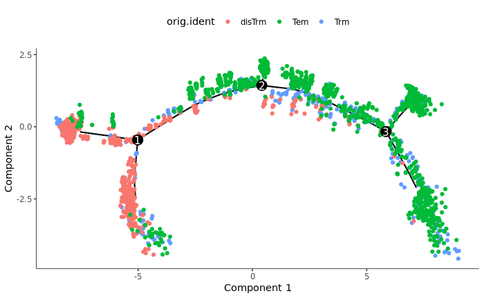

```r
plot_cell_trajectory(cds.oc, color_by = "orig.ident")
```

## 4. Test for DE over psuedotime

Pull out all “Il” genes. Subset the CellDataSet to the “Il” genes.

```r
fData(cds.oc) %>%
  pull(gene_short_name) -> all.ordered.genes

marker_genes <- grep('^Il', all.ordered.genes, value = T)
marker_genes
```

```
 [1] "Il18r1"  "Il18rap" "Ilkap"   "Il2ra"   "Il15ra"  "Il2rg"   "Il2"     "Il6ra"   "Ilf2"    "Il17ra"  "Il16"    "Ilk"     "Il4ra"
[14] "Il21r"   "Ilvbl"   "Il27ra"  "Ilf3"    "Il10ra"  "Il6st"   "Il7r"    "Il2rb"   "Il10rb"
```

```r
cds.mg <- cds.oc[marker_genes,]
cds.mg
```

```
CellDataSet (storageMode: environment)
assayData: 22 features, 2779 samples
  element names: exprs
protocolData: none
phenoData
  sampleNames: Trm_AAACCTGGTCTTGCGG Trm_AAACGGGAGGCTCAGA ... Tem_TTTGTCACATCTCCCA (2779 total)
  varLabels: orig.ident nCount_RNA ... State (10 total)
  varMetadata: labelDescription
featureData
  featureNames: Il18r1 Il18rap ... Il10rb (22 total)
  fvarLabels: gene_short_name num_cells_expressed use_for_ordering
  fvarMetadata: labelDescription
experimentData: use 'experimentData(object)'
Annotation:
```

Test whether the expression of each gene varies with pseudotime.

```r
diff_test_res2 <- differentialGeneTest(cds.mg, fullModelFormulaStr = "~sm.ns(Pseudotime)")
diff_test_res2
```

|  | status | family | pval | qval | gene_short_name | num_cells_expressed | use_for_ordering |
| --- | --- | --- | --- | --- | --- | --- | --- |
| Il18r1 | OK | negbinomial.size | 6.489983e-154 | 1.427796e-152 | Il18r1 | 1210 | TRUE |
| Il18rap | OK | negbinomial.size | 6.257838e-13 | 2.753449e-12 | Il18rap | 216 | TRUE |
| Ilkap | OK | negbinomial.size | 8.383425e-01 | 8.383425e-01 | Ilkap | 578 | FALSE |
| Il2ra | OK | negbinomial.size | 4.315236e-22 | 3.164506e-21 | Il2ra | 161 | TRUE |
| Il15ra | OK | negbinomial.size | 1.032385e-01 | 1.336027e-01 | Il15ra | 111 | FALSE |
| Il2rg | OK | negbinomial.size | 8.718242e-06 | 1.743648e-05 | Il2rg | 1384 | FALSE |
| Il2 | OK | negbinomial.size | 3.310799e-21 | 1.820940e-20 | Il2 | 461 | TRUE |
| Il6ra | OK | negbinomial.size | 3.876050e-08 | 1.065914e-07 | Il6ra | 328 | TRUE |
| Ilf2 | OK | negbinomial.size | 4.130785e-04 | 6.990559e-04 | Ilf2 | 524 | TRUE |
| Il17ra | OK | negbinomial.size | 9.314943e-10 | 2.927553e-09 | Il17ra | 703 | TRUE |

[output cut: 12 more lines]

Notice how the model formula is specified. The term “Pseudotime” refers to the column in phenoData.

```r
head(pData(cds.mg))
```

|  | orig.ident | nCount_RNA | nFeature_RNA | percent.mt | RNA_snn_res.0.6 | seurat_clusters | Size_Factor | num_genes_expressed | Pseudotime | State |
| --- | --- | --- | --- | --- | --- | --- | --- | --- | --- | --- |
| Trm_AAACCTGGTCTTGCGG | Trm | 4480 | 1544 | 2.343750 | 1 | 1 | 1.2502888 | 1544 | 5.576941 | 3 |
| Trm_AAACGGGAGGCTCAGA | Trm | 7628 | 1696 | 3.224961 | 0 | 0 | 2.1288399 | 1696 | 15.386912 | 4 |
| Trm_AAACGGGGTCAACATC | Trm | 4830 | 1572 | 2.939959 | 0 | 0 | 1.3479676 | 1572 | 6.908313 | 3 |
| Trm_AAACGGGTCTTGAGAC | Trm | 8058 | 2239 | 2.593696 | 1 | 1 | 2.2488453 | 2239 | 3.603911 | 1 |
| Trm_AAAGATGGTAGGGTAC | Trm | 2378 | 1003 | 3.195963 | 0 | 0 | 0.6636577 | 1003 | 8.283603 | 3 |
| Trm_AAAGATGTCCTACAGA | Trm | 2934 | 1027 | 2.453988 | 3 | 3 | 0.8188275 | 1027 | 12.949319 | 4 |

Then, `Pseudotime` is surrounded by the function `sm.ns()`, which is defined in the R package VGAM. It is a “smart” version of splines::ns() that specifies the model as a spline regression.

```r
?sm.ns()
?ns()
```

Select genes that are significant at an FDR < 5%

```r
diff_test_res2 %>%
  filter(qval < 0.05) -> sig_genes
sig_genes
```

|  | status | family | pval | qval | gene_short_name | num_cells_expressed | use_for_ordering |
| --- | --- | --- | --- | --- | --- | --- | --- |
| Il18r1 | OK | negbinomial.size | 6.489983e-154 | 1.427796e-152 | Il18r1 | 1210 | TRUE |
| Il18rap | OK | negbinomial.size | 6.257838e-13 | 2.753449e-12 | Il18rap | 216 | TRUE |
| Il2ra | OK | negbinomial.size | 4.315236e-22 | 3.164506e-21 | Il2ra | 161 | TRUE |
| Il2rg | OK | negbinomial.size | 8.718242e-06 | 1.743648e-05 | Il2rg | 1384 | FALSE |
| Il2 | OK | negbinomial.size | 3.310799e-21 | 1.820940e-20 | Il2 | 461 | TRUE |
| Il6ra | OK | negbinomial.size | 3.876050e-08 | 1.065914e-07 | Il6ra | 328 | TRUE |
| Ilf2 | OK | negbinomial.size | 4.130785e-04 | 6.990559e-04 | Ilf2 | 524 | TRUE |
| Il17ra | OK | negbinomial.size | 9.314943e-10 | 2.927553e-09 | Il17ra | 703 | TRUE |
| Ilk | OK | negbinomial.size | 2.079073e-05 | 3.811634e-05 | Ilk | 593 | FALSE |
| Il4ra | OK | negbinomial.size | 2.503606e-07 | 6.119926e-07 | Il4ra | 270 | TRUE |

[output cut: 6 more lines]

```r
cds.mg1 <- cds.mg[sig_genes$gene_short_name,]
cds.mg1
```

```
CellDataSet (storageMode: environment)
assayData: 16 features, 2779 samples
  element names: exprs
protocolData: none
phenoData
  sampleNames: Trm_AAACCTGGTCTTGCGG Trm_AAACGGGAGGCTCAGA ... Tem_TTTGTCACATCTCCCA (2779 total)
  varLabels: orig.ident nCount_RNA ... State (10 total)
  varMetadata: labelDescription
featureData
  featureNames: Il18r1 Il18rap ... Il2rb (16 total)
  fvarLabels: gene_short_name num_cells_expressed use_for_ordering
  fvarMetadata: labelDescription
experimentData: use 'experimentData(object)'
Annotation:
```

Plot individual genes

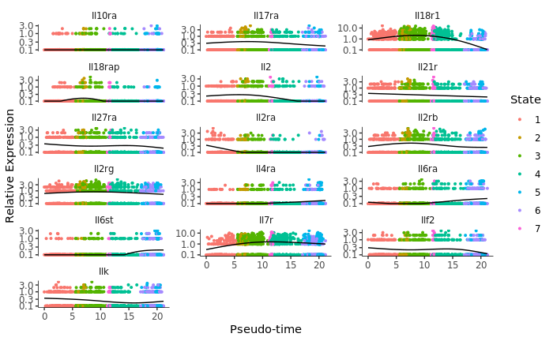

```r
plot_genes_in_pseudotime(cds.mg1, ncol=3)
```